# Universidade Federal do Amazonas Departamento de Estatística

Curso: Introdução à Ciência de Dados Professor: Leonardo Nascimento 11/01/2024 Versão 1.0

# 1 Environments

## 1.1 Conceitos iniciais

- Ambientes (environments) em R são estruturas de dados que representam **espaços** onde objetos, como variáveis e funções, são associados a nomes.
- Você pode pensar em um ambiente como um conjunto de nomes, sem ordem implícita.

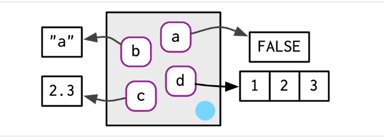

- No exemplo abaixo, estamos criando uma associação do símbolo `nome` ao valor `Leonardo`, que, por padrão, é guardada dentro do *global environment*.

```r
nome <- "Leonardo"
ls(globalenv())
```

```
## [1] "nome"
```

```r
nome
```

```
## [1] "Leonardo"
```

- Nesse caso, quando “chamarmos” o símbolo `nome` , o R vai procurar dentro desse *environment* um valor para devolver
- É possível criar novos *environments* com a função `new.env()` ou `rlang::env()`

```r
novo_ambiente = new.env() # criando o ambiente
novo_ambiente$nome <- "Nascimento" #criando objeto dentro do ambiente ou
assign(nome,"Nascimento",envir = novo_ambiente ) #criando objeto dentro do ambiente
nome
```

```
## [1] "Leonardo"
```

```r
get("nome",envir = novo_ambiente)
```

```
## [1] "Nascimento"
```

- Note que o R inicia a busca no *global environment*.
- Use a função `rlang::env_print()` para mais informações sobre o ambiente

```r
rlang::env_print(novo_ambiente)
```

```
## <environment: 0x0000017383e64008>
## Parent: <environment: global>
## Bindings:
## • nome: <chr>
## • Leonardo: <chr>
```

- Vamos criar outro objeto dentro de `novo_ambiente`.

```r
novo_ambiente$idade = 30
rlang::env_print(novo_ambiente)
```

```
## <environment: 0x0000017383e64008>
## Parent: <environment: global>
## Bindings:
## • nome: <chr>
## • Leonardo: <chr>
## • idade: <dbl>
```

## 1.2 Relações entre Ambientes

```r
novo_ambiente$idade = 30
idade
```

[output not shown]

- Nesse caso, o R não vai encontrar um valor para associar, pois `novo_ambiente` é um *environment* “abaixo” do *global* na **hierarquia**, e o R só estende a sua busca para *environments* acima .

```r
a = 1 # criando um objeto no ambiente global
get("a",envir = novo_ambiente) # buscar o objeto "a" no ambiente novo_ambiente
```

```
## [1] 1
```

- Para saber qual ambiente está acima, podemos usar a função `parent.env()`

```r
parent.env(novo_ambiente)
```

```
## <environment: R_GlobalEnv>
```

- Portanto, quando o R não encontra um valor para um símbolo no *environment* em que está procurando, ele passa a procurar no próximo, **o *environment* para qual o primeiro está apontando**, chamado de *environment pai*. Assim, os *environments* se estruturam em uma hierárquia.

```r
novo_ambiente_2 = new.env(parent = novo_ambiente)
parent.env(novo_ambiente_2)
```

```
## <environment: 0x0000017383e64008>
```

```r
rlang::env_print(novo_ambiente)
```

```
## <environment: 0x0000017383e64008>
## Parent: <environment: global>
## Bindings:
## • nome: <chr>
## • Leonardo: <chr>
## • idade: <dbl>
```

```r
rlang::env_parents(novo_ambiente_2)
```

```
## [[1]]   <env: 0x0000017383e64008>
## [[2]] $ <env: global>
```

- Essa estrutura é muito útil na hora de utilizar funções
- Apenas um ambiente não possui pai: o ambiente **vazio**

```r
rlang::env_parents(novo_ambiente_2,last = rlang::empty_env())
```

```
##  [[1]]   <env: 0x0000017383e64008>
##  [[2]] $ <env: global>
##  [[3]] $ <env: package:stats>
##  [[4]] $ <env: package:graphics>
##  [[5]] $ <env: package:grDevices>
##  [[6]] $ <env: package:utils>
##  [[7]] $ <env: package:datasets>
##  [[8]] $ <env: package:methods>
##  [[9]] $ <env: Autoloads>
## [[10]] $ <env: package:base>
## [[11]] $ <env: empty>
```

```r
novo_ambiente_3 = new.env(parent = rlang::empty_env())
rlang::env_parents(novo_ambiente_3)
```

```
## [[1]] $ <env: empty>
```

- O ambiente atual ou `current_env()`é o ambiente no qual o código está sendo executado no momento.

```r
rlang::current_env()
```

```
## <environment: R_GlobalEnv>
```

```r
identical(globalenv(), environment()) #ou
```

```
## [1] TRUE
```

```r
identical(rlang::global_env(), rlang::current_env())
```

```
## [1] TRUE
```

## 1.3 Superatribuição

- A atribuição regular, `<-`sempre cria uma variável no ambiente atual.
- A superatribuição `<<-`nunca cria uma variável no ambiente atual, mas modifica uma variável existente encontrada em um **ambiente pai**.

```r
x <- 0
f <- function() {
  x <<- 1
}
f()
x
```

```
## [1] 1
```

[output not shown]

## 1.4 Ambientes Especiais

### 1.4.1 Ambientes de pacote

- Cada pacote anexado `library()`ou `require()`torna-se um dos pais do ambiente global.
- O pai imediato do ambiente global é o último pacote que você anexou e o pai desse pacote é o penúltimo pacote que você anexou

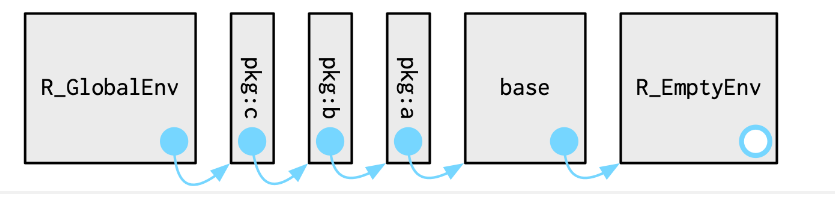

- Se você seguir todos os pais, verá a ordem em que cada pacote foi anexado. Isso é conhecido como **caminho de pesquisa**
- Você pode ver os nomes desses ambientes com `base::search()`ou os próprios ambientes com `rlang::search_envs()`:

```r
search()
```

```
## [1] ".GlobalEnv"        "package:stats"     "package:graphics"
## [4] "package:grDevices" "package:utils"     "package:datasets"
## [7] "package:methods"   "Autoloads"         "package:base"
```

```r
rlang::search_envs()
```

```
## [[1]] $ <env: global>
## [[2]] $ <env: package:stats>
## [[3]] $ <env: package:graphics>
## [[4]] $ <env: package:grDevices>
## [[5]] $ <env: package:utils>
## [[6]] $ <env: package:datasets>
## [[7]] $ <env: package:methods>
## [[8]] $ <env: Autoloads>
## [[9]] $ <env: package:base>
```

### 1.4.2 Ambiente de funções

- Ambientes nos quais as funções criadas foram vinculadas

```r
y <- 1
f <- function(x) x + y
environment(f)
```

```
## <environment: R_GlobalEnv>
```

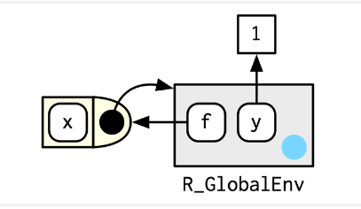

```r
criar_funcao <- function() {

  funcao_interna <- function() {
    a=1
    print("aqui")
    list(ran.in = rlang::current_env(),
         parent = rlang::env_parent(rlang::current_env()),
         objects = ls.str(rlang::current_env()))
  }
  return(funcao_interna)
}
minha_funcao <- criar_funcao()
minha_funcao()
```

```
## [1] "aqui"
```

```
## $ran.in
## <environment: 0x00000173804bcad8>
##
## $parent
## <environment: 0x0000017380469918>
##
## $objects
## a :  num 1
```

```r
environment(minha_funcao)
```

```
## <environment: 0x0000017380469918>
```

```r
environment(criar_funcao)
```

```
## <environment: R_GlobalEnv>
```

### 1.4.3 Ambiente de Execução

- Cada vez que uma função é chamada, um novo ambiente é criado para hospedar a execução. Isso é chamado de ambiente de execução e seu pai é o ambiente de função.
- Eles contêm variáveis locais e referências a variáveis em escopos superiores, como o ambiente global ou ambientes de funções encapsuladoras.
- Cada chamada de função tem seu próprio ambiente de execução, isolado dos ambientes de execução de outras chamadas da mesma função.
- É assim que R garante que uma função não sobrescreva nada que não deveria. Quaisquer objetos criados pela função são armazenados em um ambiente de tempo de execução seguro e afastado.

```r
show_env <- function(){
  a = 1
  list(ran.in = rlang::current_env(),
    parent = rlang::env_parent(rlang::current_env()),
    objects = ls.str(rlang::current_env()))
}
show_env()
```

```
## $ran.in
## <environment: 0x00000173808384a0>
##
## $parent
## <environment: R_GlobalEnv>
##
## $objects
## a :  num 1
```

```r
x = 10
a = 4
x+a
```

```
## [1] 14
```

```r
h <- function(x) {
  # 1.
  a <- 2 # 2.
  x + a
}
y <- h(1) # 3.
y
```

```
## [1] 3
```

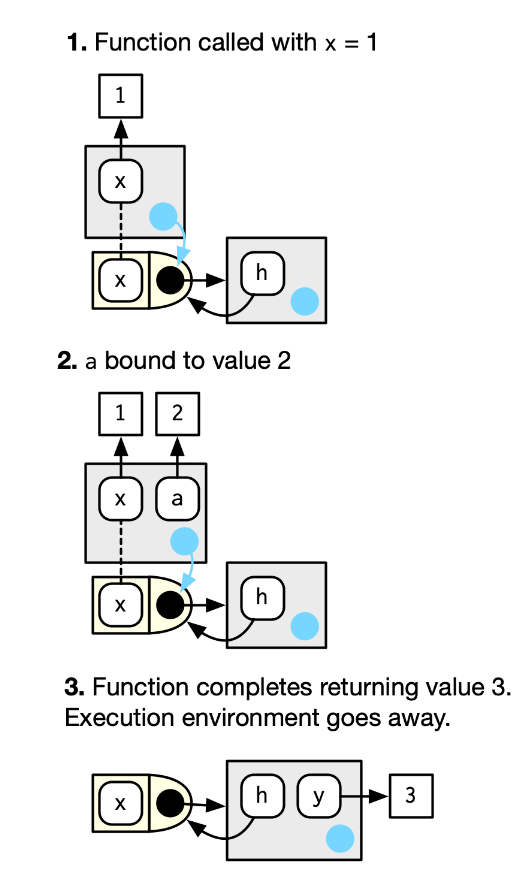

- Portanto, se você salvar o resultado da função em um objeto com `<-`, o novo objeto será armazenado no ambiente de chamada.

# 2 Programação Funcional

- *A **functional** is a function that takes a function as an input and returns a vector as output*

```r
rf <- function(f) f(rnorm(100))
rf(mean)
```

```
## [1] 0.09729014
```

```r
rf(sum)
```

```
## [1] -11.12911
```

- Alguns exemplos: `lapply()`, `apply()`, e `tapply()`; funcional matemático como `integrate()`ou `optim()`.
- Aqui, será apresentado a família `purrr::map`
- O funcional mais fundamental é `purrr::map()`. Ele pega um vetor e uma função, chama a função uma vez para cada elemento do vetor e retorna os resultados em uma lista.

```r
x = NULL
y = 1:10
for(i in 1:length(y)){
  x[i] <- 2*y[i]
}
x
```

```
##  [1]  2  4  6  8 10 12 14 16 18 20
```

```r
f = function(x){2*x}
purrr::map(y,f)
```

```
## [[1]]
## [1] 2
##
## [[2]]
## [1] 4
##
## [[3]]
## [1] 6
##
## [[4]]
## [1] 8
##
## [[5]]
## [1] 10
##
## [[6]]
## [1] 12
##
## [[7]]
## [1] 14
##
## [[8]]
## [1] 16
##
## [[9]]
## [1] 18
##
## [[10]]
## [1] 20
```

- `map()`retorna uma lista, o que a torna a mais geral da família de mapas.
- Mas é inconveniente retornar uma lista quando uma estrutura de dados mais simples serviria, então existem mais quatro variantes específicas: `map_lgl()`, `map_int()`, `map_dbl()`, e `map_chr()`

```r
require(purrr)
head(mtcars)
```

```
##                    mpg cyl disp  hp drat    wt  qsec vs am gear carb
## Mazda RX4         21.0   6  160 110 3.90 2.620 16.46  0  1    4    4
## Mazda RX4 Wag     21.0   6  160 110 3.90 2.875 17.02  0  1    4    4
## Datsun 710        22.8   4  108  93 3.85 2.320 18.61  1  1    4    1
## Hornet 4 Drive    21.4   6  258 110 3.08 3.215 19.44  1  0    3    1
## Hornet Sportabout 18.7   8  360 175 3.15 3.440 17.02  0  0    3    2
## Valiant           18.1   6  225 105 2.76 3.460 20.22  1  0    3    1
```

```r
map_chr(mtcars, typeof) # character
```

```
##      mpg      cyl     disp       hp     drat       wt     qsec       vs
## "double" "double" "double" "double" "double" "double" "double" "double"
##       am     gear     carb
## "double" "double" "double"
```

```r
map_lgl(mtcars, is.double) # lógical
```

```
##  mpg  cyl disp   hp drat   wt qsec   vs   am gear carb
## TRUE TRUE TRUE TRUE TRUE TRUE TRUE TRUE TRUE TRUE TRUE
```

```r
map_int(mtcars, ~length(unique(x))) # inteiro
```

```
##  mpg  cyl disp   hp drat   wt qsec   vs   am gear carb
##   10   10   10   10   10   10   10   10   10   10   10
```

```r
#map_int(mtcars, function(x) length(unique(x))) # inteiro
map_dbl(mtcars, mean) # double
```

```
##        mpg        cyl       disp         hp       drat         wt       qsec
##  20.090625   6.187500 230.721875 146.687500   3.596563   3.217250  17.848750
##         vs         am       gear       carb
##   0.437500   0.406250   3.687500   2.812500
```

- Selecionando Elementos

```r
x <- list(
  list(5, x = 2, y = c(1), z = "A"),
  list(9, x = 1, y = c(1, 6), z = "B"),
  list(2, x = 10, y = c(2, 3, 5))
)

map_dbl(x, "x")
```

```
## [1]  2  1 10
```

```r
map_dbl(x, 1)
```

```
## [1] 5 9 2
```

```r
map_dbl(x, list("y", 1))
```

```
## [1] 1 1 2
```

```r
map_chr(x, "z", .default = NA)
```

```
## [1] "A" "B" NA
```

```r
dados_json <- '[
  {"nome": "Alice", "idade": 25, "cidade": "São Paulo"},
  {"nome": "Bob", "idade": 30, "cidade": "Rio de Janeiro"},
  {"nome": "Charlie", "idade": 22, "cidade": "Belo Horizonte"}
]'

lista_pessoas <- rjson::fromJSON(dados_json)

# Usar map para extrair os nomes de cada pessoa
(nomes <- map_chr(lista_pessoas, "nome"))
```

```
## [1] "Alice"   "Bob"     "Charlie"
```

```r
(idade <- map_dbl(lista_pessoas, 2))
```

```
## [1] 25 30 22
```

- O primeiro argumento for constante e você quiser variar um argumento diferente

```r
trims <- c(0, 0.1, 0.2, 0.5)
x <- rcauchy(1000)

map_dbl(trims, ~ mean(x, trim = .))#
```

```
## [1] -0.448260067  0.008575166 -0.010866053 -0.008689325
```

- Gerar variáveis aleatórias

```r
map(1:3, ~ rnorm(2))
```

```
## [[1]]
## [1] 0.05802109 0.08143811
##
## [[2]]
## [1] -0.87569135  0.04148435
##
## [[3]]
## [1] -0.5745417 -0.5325237
```

- Variação: `map2()`
- `map()`é vetorizado em um único argumento, `.x`. Isso significa que ele varia apenas `.x`durante a chamada `.f`e todos os outros argumentos são transmitidos inalterados.
- Considere, por exemplo, encontrar uma média ponderada para uma lista de observações e uma lista de pesos

```r
obs <- list(c(1,2,3),c(4,5,NA))
wd <- list(c(1,2,3),c(4,5,6))
map2_dbl(obs,wd,weighted.mean,na.rm=T)
```

```
## [1] 2.333333 4.555556
```

- Variação `pmap()`

```r
obs <- list(c(1,2,3),c(4,5,NA))
wd <- list(c(1,2,3),c(4,5,6))
pmap_dbl(list(obs, wd), weighted.mean, na.rm = TRUE)
```

```
## [1] 2.333333 4.555556
```

```r
n = list(1,2,3)
min = list(0,10,100)
max = list(1,100,1000)
pmap(list(n,min,max),runif)
```

```
## [[1]]
## [1] 0.1447121
##
## [[2]]
## [1] 70.49285 93.74458
##
## [[3]]
## [1] 687.1049 402.7212 379.8194
```

# 3 Programação Paralela

- Muitos cálculos em R podem ser feitos mais rapidamente pelo uso de computação paralela.
- Geralmente, a computação paralela é a execução simultânea de diferentes partes de uma computação maior em vários processadores ou núcleos de computação
- Os núcleos de um computador se referem às unidades de processamento que podem executar instruções independentes.

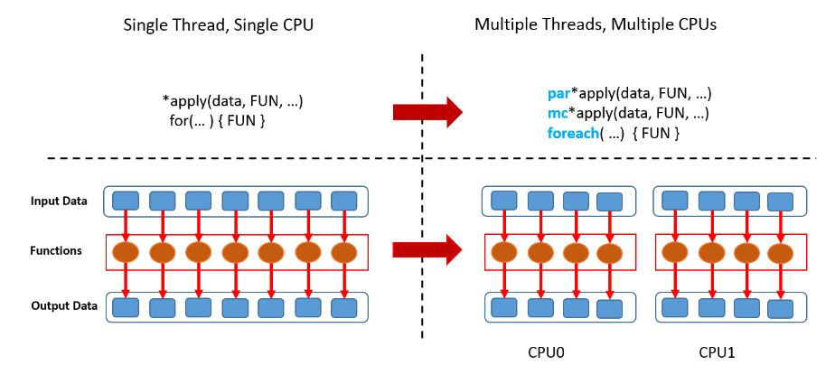

## 3.1 Pacote snowfall

```r
library(parallel)
num_nucleos <- detectCores()
nucleos = round(0.60*num_nucleos)

f <- function(i) {
  return(lm(Petal.Width ~  Species, data = iris))
}

require(snowfall)
sfInit(parallel=TRUE, cpus=nucleos)
sfExportAll() # exportar os objetos para todos os núcleos
sfLibrary("nome_pacote") # exportar o pacote para todos os núcleos
system.time(sfLapply(1:100000, fun=f))
sfStop()
system.time(
for(i in 1:100000){
  f(i)
}
)
```

[output not shown]

# 4 Referências

- [Advanced R](https://adv-r.hadley.nz/index.html)
- [R for Data Science](https://r4ds.had.co.nz/index.html)
- [Hands-On Programming with R](https://web.itu.edu.tr/~tokerem/Hands-On_R.pdf)